# Project

Giordano Vitale

2023-05-22

```r
df <- read.csv('dataset\\airline_passenger_satisfaction.csv')
head(df)
```

```
##   X Gender     customer_type age  type_of_travel customer_class flight_distance
## 1 0   Male    Loyal Customer  13 Personal Travel       Eco Plus             460
## 2 1   Male disloyal Customer  25 Business travel       Business             235
## 3 2 Female    Loyal Customer  26 Business travel       Business            1142
## 4 3 Female    Loyal Customer  25 Business travel       Business             562
## 5 4   Male    Loyal Customer  61 Business travel       Business             214
## 6 5 Female    Loyal Customer  26 Personal Travel            Eco            1180
##   inflight_wifi_service departure_arrival_time_convenient
## 1                     3                                 4
## 2                     3                                 2
## 3                     2                                 2
## 4                     2                                 5
## 5                     3                                 3
## 6                     3                                 4
##   ease_of_online_booking gate_location food_and_drink online_boarding
```

[output cut: 27 more lines]

```r
df <- df[, -1]
```

Consider the non-NA values only.

```r
df <- na.omit(df)
head(df)
```

```
##   Gender     customer_type age  type_of_travel customer_class flight_distance
## 1   Male    Loyal Customer  13 Personal Travel       Eco Plus             460
## 2   Male disloyal Customer  25 Business travel       Business             235
## 3 Female    Loyal Customer  26 Business travel       Business            1142
## 4 Female    Loyal Customer  25 Business travel       Business             562
## 5   Male    Loyal Customer  61 Business travel       Business             214
## 6 Female    Loyal Customer  26 Personal Travel            Eco            1180
##   inflight_wifi_service departure_arrival_time_convenient
## 1                     3                                 4
## 2                     3                                 2
## 3                     2                                 2
## 4                     2                                 5
## 5                     3                                 3
## 6                     3                                 4
##   ease_of_online_booking gate_location food_and_drink online_boarding
```

[output cut: 27 more lines]

```r
str(df)
```

```
## 'data.frame':    129487 obs. of  23 variables:
##  $ Gender                           : chr  "Male" "Male" "Female" "Female" ...
##  $ customer_type                    : chr  "Loyal Customer" "disloyal Customer" "Loyal Customer" "Loyal Customer" ...
##  $ age                              : int  13 25 26 25 61 26 47 52 41 20 ...
##  $ type_of_travel                   : chr  "Personal Travel" "Business travel" "Business travel" "Business travel" ...
##  $ customer_class                   : chr  "Eco Plus" "Business" "Business" "Business" ...
##  $ flight_distance                  : int  460 235 1142 562 214 1180 1276 2035 853 1061 ...
##  $ inflight_wifi_service            : int  3 3 2 2 3 3 2 4 1 3 ...
##  $ departure_arrival_time_convenient: int  4 2 2 5 3 4 4 3 2 3 ...
##  $ ease_of_online_booking           : int  3 3 2 5 3 2 2 4 2 3 ...
##  $ gate_location                    : int  1 3 2 5 3 1 3 4 2 4 ...
##  $ food_and_drink                   : int  5 1 5 2 4 1 2 5 4 2 ...
##  $ online_boarding                  : int  3 3 5 2 5 2 2 5 3 3 ...
##  $ seat_comfort                     : int  5 1 5 2 5 1 2 5 3 3 ...
##  $ inflight_entertainment           : int  5 1 5 2 3 1 2 5 1 2 ...
##  $ onboard_service                  : int  4 1 4 2 3 3 3 5 1 2 ...
##  $ leg_room_service                 : int  3 5 3 5 4 4 3 5 2 3 ...
##  $ baggage_handling                 : int  4 3 4 3 4 4 4 5 1 4 ...
##  $ checkin_service                  : int  4 1 4 1 3 4 3 4 4 4 ...
##  $ inflight_service                 : int  5 4 4 4 3 4 5 5 1 3 ...
##  $ cleanliness                      : int  5 1 5 2 3 1 2 4 2 2 ...
##  $ departure_delay_in_minutes       : int  25 1 0 11 0 0 9 4 0 0 ...
##  $ arrival_delay_in_minutes         : num  18 6 0 9 0 0 23 0 0 0 ...
##  $ satisfaction                     : chr  "neutral or dissatisfied" "neutral or dissatisfied" "satisfied" "neutral or dissatisfied" ...
##  - attr(*, "na.action")= 'omit' Named int [1:393] 214 1125 1530 2005 2109 2486 2631 3622 4042 4491 ...
##   ..- attr(*, "names")= chr [1:393] "214" "1125" "1530" "2005" ...
```

We need to change the support of some variables, because they are expressed as categorical, qualitative but we need the quantitative support in order to compute the correlation matrix.

```r
df$customer_class <- ifelse(df$customer_class == "Eco Plus", "Eco", df$customer_class)
df$satisfaction <- ifelse(df$satisfaction == "satisfied", 1, 0)
df$Gender <- ifelse(df$Gender == "Male", 1, 0)
df$customer_type <- ifelse(df$customer_type == "Loyal Customer", 1, 0)
df$customer_class <- ifelse(df$customer_class == 'Eco', 1, 0)
df$type_of_travel <- ifelse(df$type_of_travel == 'Personal Travel', 1, 0)
```

Double check we now have all the variables in numerical support.

```r
str(df)
```

```
## 'data.frame':    129487 obs. of  23 variables:
##  $ Gender                           : num  1 1 0 0 1 0 1 0 0 1 ...
##  $ customer_type                    : num  1 0 1 1 1 1 1 1 1 0 ...
##  $ age                              : int  13 25 26 25 61 26 47 52 41 20 ...
##  $ type_of_travel                   : num  1 0 0 0 0 1 1 0 0 0 ...
##  $ customer_class                   : num  1 0 0 0 0 1 1 0 0 1 ...
##  $ flight_distance                  : int  460 235 1142 562 214 1180 1276 2035 853 1061 ...
##  $ inflight_wifi_service            : int  3 3 2 2 3 3 2 4 1 3 ...
##  $ departure_arrival_time_convenient: int  4 2 2 5 3 4 4 3 2 3 ...
##  $ ease_of_online_booking           : int  3 3 2 5 3 2 2 4 2 3 ...
##  $ gate_location                    : int  1 3 2 5 3 1 3 4 2 4 ...
##  $ food_and_drink                   : int  5 1 5 2 4 1 2 5 4 2 ...
##  $ online_boarding                  : int  3 3 5 2 5 2 2 5 3 3 ...
##  $ seat_comfort                     : int  5 1 5 2 5 1 2 5 3 3 ...
##  $ inflight_entertainment           : int  5 1 5 2 3 1 2 5 1 2 ...
##  $ onboard_service                  : int  4 1 4 2 3 3 3 5 1 2 ...
##  $ leg_room_service                 : int  3 5 3 5 4 4 3 5 2 3 ...
##  $ baggage_handling                 : int  4 3 4 3 4 4 4 5 1 4 ...
##  $ checkin_service                  : int  4 1 4 1 3 4 3 4 4 4 ...
##  $ inflight_service                 : int  5 4 4 4 3 4 5 5 1 3 ...
##  $ cleanliness                      : int  5 1 5 2 3 1 2 4 2 2 ...
##  $ departure_delay_in_minutes       : int  25 1 0 11 0 0 9 4 0 0 ...
##  $ arrival_delay_in_minutes         : num  18 6 0 9 0 0 23 0 0 0 ...
##  $ satisfaction                     : num  0 0 1 0 1 0 0 1 0 0 ...
##  - attr(*, "na.action")= 'omit' Named int [1:393] 214 1125 1530 2005 2109 2486 2631 3622 4042 4491 ...
##   ..- attr(*, "names")= chr [1:393] "214" "1125" "1530" "2005" ...
```

Check if it worked correctly.

```r
sum(is.na(df))
```

```
## [1] 0
```

Once checked, compute the correlation between the variable “satisfaction” and all the other ones.

```r
correlation <- cor(df[, -which(names(df) == "satisfaction")], df$satisfaction, use = "complete.obs")
correlation
```

```
##                                           [,1]
## Gender                             0.011496124
## customer_type                      0.185925093
## age                                0.134001184
## type_of_travel                    -0.449793888
## customer_class                    -0.502604947
## flight_distance                    0.298205651
## inflight_wifi_service              0.283291139
## departure_arrival_time_convenient -0.054456512
## ease_of_online_booking             0.168704483
## gate_location                     -0.002922783
## food_and_drink                     0.211163997
## online_boarding                    0.501620304
## seat_comfort                       0.348575948
## inflight_entertainment             0.398333914
## onboard_service                    0.322329157
## leg_room_service                   0.312557025
## baggage_handling                   0.248651429
## checkin_service                    0.237145910
## inflight_service                   0.245027373
## cleanliness                        0.306890625
## departure_delay_in_minutes        -0.051031531
## arrival_delay_in_minutes          -0.058275093
```

Rank them for better visualization.

```r
# Extract the absolute values of the correlations
abs_correlation <- abs(correlation)

# Order the correlations in descending order
order_indices <- order(-abs_correlation)

# Sort the correlations and variable names accordingly
sorted_correlation <- correlation[order_indices]
sorted_variable_names <- rownames(correlation)[order_indices]

# Print the correlations and associated variable names in descending order
for (i in 1:length(sorted_correlation)) {
  print(paste("Variable name:", sorted_variable_names[i]))
  print(paste("Correlation:", sorted_correlation[i]))
  print("-----")
}
```

```
## [1] "Variable name: customer_class"
## [1] "Correlation: -0.502604947368645"
## [1] "-----"
## [1] "Variable name: online_boarding"
## [1] "Correlation: 0.501620303848753"
## [1] "-----"
## [1] "Variable name: type_of_travel"
## [1] "Correlation: -0.449793888054631"
## [1] "-----"
## [1] "Variable name: inflight_entertainment"
## [1] "Correlation: 0.398333913632007"
## [1] "-----"
## [1] "Variable name: seat_comfort"
## [1] "Correlation: 0.348575948090374"
## [1] "-----"
```

[output cut: 51 more lines]

# Logistic Model - including all the variables

Create test and training set

```r
library(caret)
split_train_test <- createDataPartition(df$satisfaction, p=0.8, list=FALSE)
dtrain <- df[split_train_test,]
dtest <-  df[-split_train_test,]
```

Build the *Logistic Model* on the training set.(all variables)

```r
logistic_model <-glm(satisfaction ~., data=dtrain , family="binomial" )

summary <- summary (logistic_model)
round(summary$coefficients, digits = 3)
```

```
##                                   Estimate Std. Error z value Pr(>|z|)
## (Intercept)                         -7.796      0.079 -99.233    0.000
## Gender                               0.053      0.019   2.729    0.006
## customer_type                        2.011      0.030  67.966    0.000
## age                                 -0.008      0.001 -11.707    0.000
## type_of_travel                      -2.744      0.031 -87.730    0.000
## customer_class                      -0.722      0.025 -29.183    0.000
## flight_distance                      0.000      0.000  -1.264    0.206
## inflight_wifi_service                0.394      0.011  34.409    0.000
## departure_arrival_time_convenient   -0.130      0.008 -15.914    0.000
## ease_of_online_booking              -0.139      0.011 -12.285    0.000
## gate_location                        0.014      0.009   1.487    0.137
## food_and_drink                      -0.032      0.011  -2.997    0.003
## online_boarding                      0.607      0.010  59.330    0.000
## seat_comfort                         0.065      0.011   5.816    0.000
## inflight_entertainment               0.061      0.014   4.273    0.000
## onboard_service                      0.302      0.010  29.641    0.000
## leg_room_service                     0.247      0.009  28.961    0.000
## baggage_handling                     0.132      0.011  11.562    0.000
## checkin_service                      0.322      0.009  37.740    0.000
## inflight_service                     0.129      0.012  10.718    0.000
## cleanliness                          0.231      0.012  19.076    0.000
## departure_delay_in_minutes           0.004      0.001   4.254    0.000
## arrival_delay_in_minutes            -0.009      0.001  -9.161    0.000
```

Predict the points of the *test set* using the Logistic Model above implemented:

```r
logistic_prediction <- predict(logistic_model, dtest, type="response")
```

Confusion Matrix to evaluate the goodness:

```r
# Set a threshold for classification
threshold <- 0.5

# Convert the predicted probabilities (through logistic model) to binary predictions based on the threshold
logistic_prediction_binary <- ifelse(logistic_prediction > threshold, 1, 0)

# Create a table of predicted values vs. actual values
confusion_matrix <- table(logistic_prediction_binary, dtest$satisfaction)

# Print the confusion table
print(confusion_matrix)
```

```
##
## logistic_prediction_binary     0     1
##                          0 13112  1864
##                          1  1394  9527
```

```r
print(mean(logistic_prediction_binary==dtest$satisfaction))
```

```
## [1] 0.8741939
```

We obtained a fraction of ~87% observation of the test set correctly predicted.

Plot the ROC Curve (https://www.displayr.com/what-is-a-roc-curve-how-to-interpret-it/)

```r
library(pROC)
```

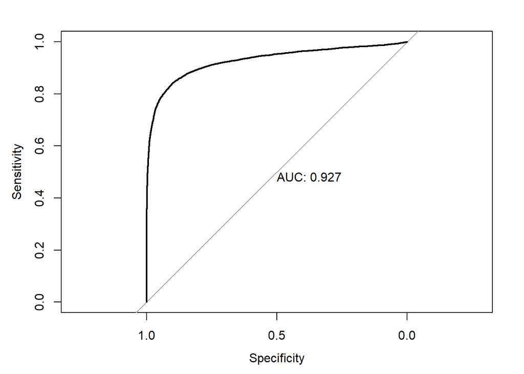

```r
test_roc = roc(dtest$satisfaction ~ logistic_prediction, plot = TRUE, print.auc = TRUE)
```

# Linear Discriminant Analysis

Build the *LDA* model

```r
library(MASS)

lda_model <- lda(satisfaction~.,data = dtrain)
lda_model
```

```
## Call:
## lda(satisfaction ~ ., data = dtrain)
##
## Prior probabilities of groups:
##         0         1
## 0.5668404 0.4331596
##
## Group means:
##      Gender customer_type      age type_of_travel customer_class
## 0 0.4881555     0.7545258 37.65240     0.49190211      0.7407142
## 1 0.4982505     0.8993114 41.75251     0.07169441      0.2357425
##   flight_distance inflight_wifi_service departure_arrival_time_convenient
## 0        930.7182              2.399581                          3.126790
## 1       1531.1414              3.154443                          2.961958
##   ease_of_online_booking gate_location food_and_drink online_boarding
## 0               2.552036      2.977367       2.958003        2.660314
## 1               3.024894      2.968398       3.526888        4.025629
##   seat_comfort inflight_entertainment onboard_service leg_room_service
## 0     3.038148               2.891126        3.020062         2.989101
## 1     3.966905               3.965479        3.856032         3.819393
##   baggage_handling checkin_service inflight_service cleanliness
## 0         3.376352        3.041247         3.387847    2.930687
## 1         3.966861        3.645450         3.972298    3.747409
##   departure_delay_in_minutes arrival_delay_in_minutes
## 0                   16.39124                 17.09145
## 1                   12.45593                 12.53551
##
## Coefficients of linear discriminants:
##                                             LD1
## Gender                             3.533789e-02
## customer_type                      1.244968e+00
## age                               -3.910055e-03
## type_of_travel                    -1.555764e+00
## customer_class                    -5.134047e-01
## flight_distance                    5.282674e-06
## inflight_wifi_service              2.747973e-01
## departure_arrival_time_convenient -6.761034e-02
## ease_of_online_booking            -1.626734e-01
## gate_location                      8.943088e-03
## food_and_drink                    -2.103948e-02
## online_boarding                    3.204404e-01
## seat_comfort                       3.066239e-02
## inflight_entertainment             6.453795e-02
## onboard_service                    1.416615e-01
## leg_room_service                   1.314582e-01
## baggage_handling                   6.734140e-02
## checkin_service                    1.496591e-01
## inflight_service                   6.057180e-02
## cleanliness                        1.072678e-01
## departure_delay_in_minutes         1.994980e-03
## arrival_delay_in_minutes          -4.018381e-03
```

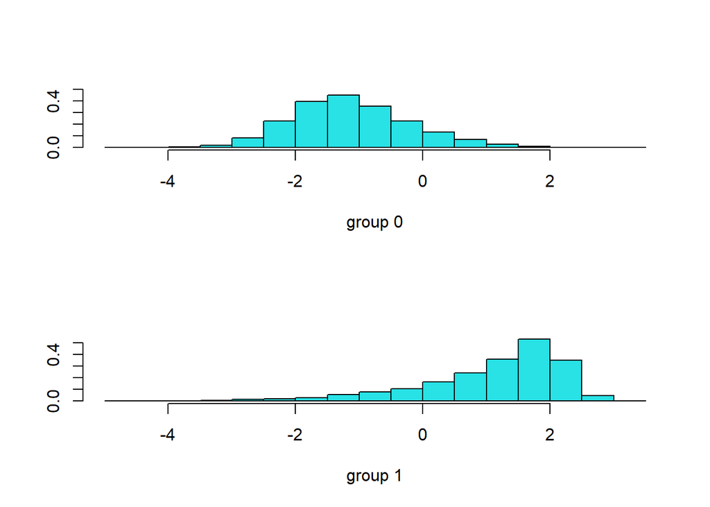

```r
plot(lda_model)
```

Predict the points of the *test set* using the *LDA Model* above implemented:

```r
lda_prediction = predict(lda_model, dtest)
lda_class_prediction = lda_prediction$class
# this prediction yields the class. This will be useful to compute the confusion matrix, because there we will not need the probabilities!
```

Output the confusion matrix

```r
table(lda_class_prediction, dtest$satisfaction)
```

```
##
## lda_class_prediction     0     1
##                    0 13028  1851
##                    1  1478  9540
```

```r
mean(lda_class_prediction==dtest$satisfaction)
```

```
## [1] 0.8714523
```

ROC for LDA

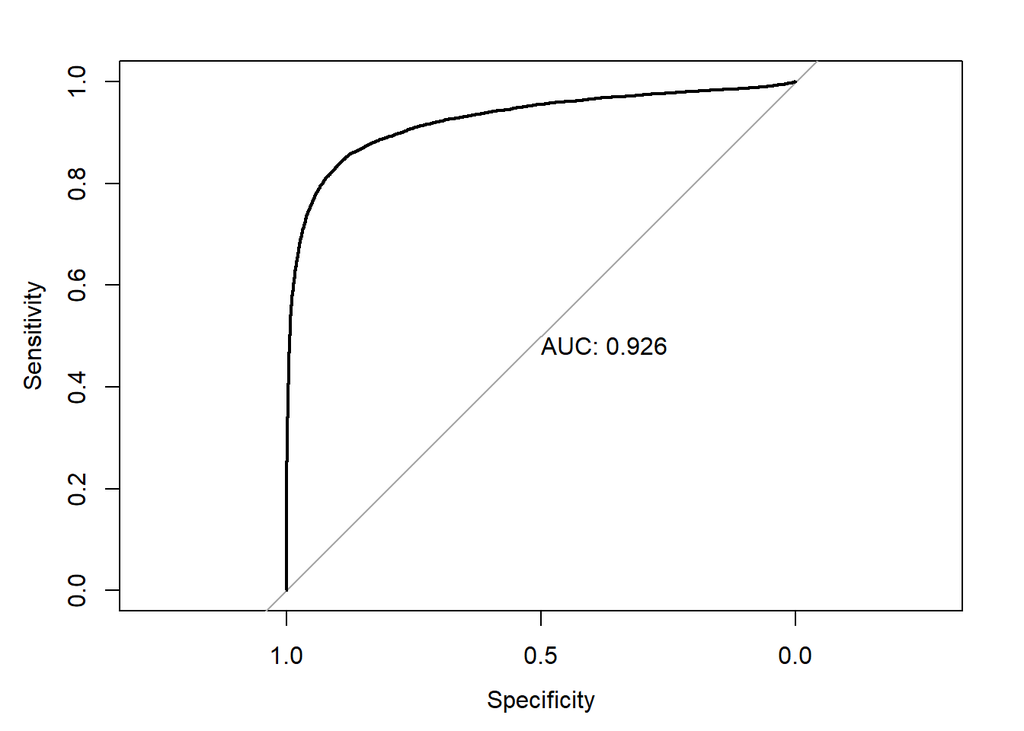

```r
lda_probabilities_prediction = lda_prediction$posterior[, "1"]  # either write 0 or 1!

# given the output produced by predict() we only take the "posterior" column, which gives us the predicted probabilities [0,1] that we need to build the ROC.
# to understand this: if you print "predict(lda_model, dtest)$posterior" we can see that we have two columns, which are complementary. So, we just need one column of them.



test_roc = roc(dtest$satisfaction ~ lda_probabilities_prediction, plot = TRUE, print.auc = TRUE)
```

# Quadratic Discriminant Analysis

```r
qda_model <- qda(satisfaction~.,data = dtrain)
qda_model
```

```
## Call:
## qda(satisfaction ~ ., data = dtrain)
##
## Prior probabilities of groups:
##         0         1
## 0.5668404 0.4331596
##
## Group means:
##      Gender customer_type      age type_of_travel customer_class
## 0 0.4881555     0.7545258 37.65240     0.49190211      0.7407142
## 1 0.4982505     0.8993114 41.75251     0.07169441      0.2357425
##   flight_distance inflight_wifi_service departure_arrival_time_convenient
## 0        930.7182              2.399581                          3.126790
## 1       1531.1414              3.154443                          2.961958
##   ease_of_online_booking gate_location food_and_drink online_boarding
## 0               2.552036      2.977367       2.958003        2.660314
## 1               3.024894      2.968398       3.526888        4.025629
##   seat_comfort inflight_entertainment onboard_service leg_room_service
## 0     3.038148               2.891126        3.020062         2.989101
## 1     3.966905               3.965479        3.856032         3.819393
##   baggage_handling checkin_service inflight_service cleanliness
## 0         3.376352        3.041247         3.387847    2.930687
## 1         3.966861        3.645450         3.972298    3.747409
##   departure_delay_in_minutes arrival_delay_in_minutes
## 0                   16.39124                 17.09145
## 1                   12.45593                 12.53551
```

Predict the points of the *test set* using the *QDA Model* above implemented:

```r
qda_prediction = predict(qda_model, dtest)
qda_class_prediction = qda_prediction$class
```

Output the confusion matrix

```r
table(qda_class_prediction, dtest$satisfaction)
```

```
##
## qda_class_prediction     0     1
##                    0 13031  2161
##                    1  1475  9230
```

```r
mean(qda_class_prediction==dtest$satisfaction)
```

```
## [1] 0.8595976
```

Plot the ROC Curve

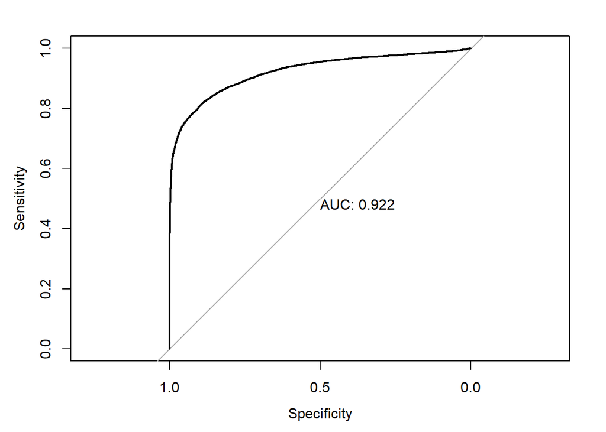

```r
qda_probabilities_prediction <- qda_prediction$posterior[,"1"]

test_roc = roc(dtest$satisfaction ~ qda_probabilities_prediction, plot = TRUE, print.auc = TRUE)
```

# knn

```r
library(class)

# create Data Domain X for the TRAINING set
train_X = dtrain[-23]

# create Data Domain X for the TEST set
test_X= dtest[-23]

# labels of the training set
train_Y = dtrain$satisfaction

# labels of the test set
test_Y = dtest$satisfaction
```

```r
library(ggplot2)

# Define the range of k values to evaluate
k_values <- c(1,3,5,7,9)

# Initialize an empty vector to store the accuracies
accuracies <- c()

# Compute the accuracy for each k value
for (k in k_values) {
  knn_prediction <- knn(train_X, test_X, train_Y, k = k)
  accuracy <- mean(knn_prediction == test_Y)
  accuracies <- c(accuracies, accuracy)
}

# Create a data frame with the k values and accuracies
acc_data <- data.frame(k = k_values, accuracy = accuracies)
```

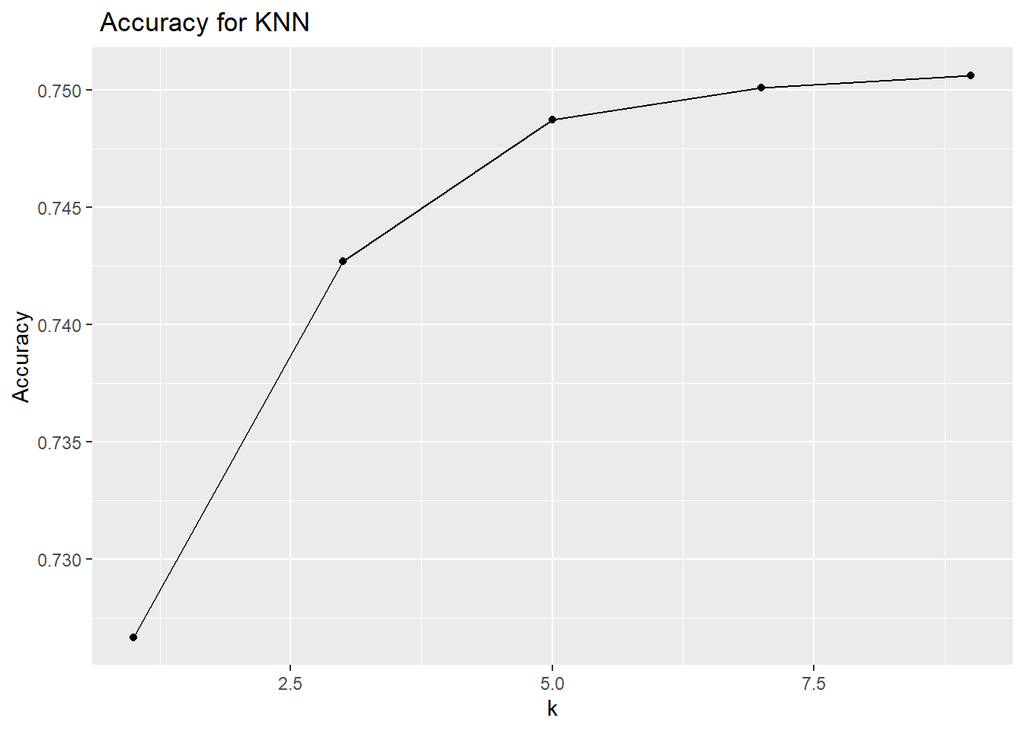

```r
# Plot the elbow plot
ggplot(acc_data, aes(x = k, y = accuracy)) +
  geom_line() +
  geom_point() +
  labs(x = "k", y = "Accuracy") +
  ggtitle(" Accuracy for KNN")
```

Error Rate plot

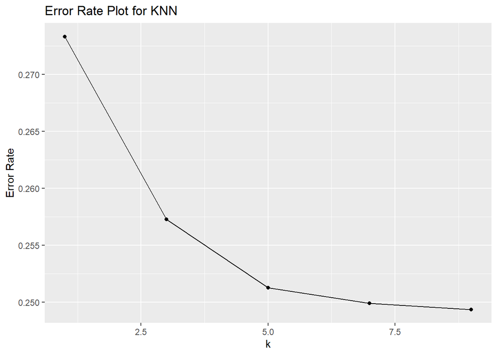

```r
# Initialize an empty vector to store the error rates
error_rates <- c()
k_values <- c(1,3,5,7,9)

for (i in acc_data$accuracy){
error_rate <- 1 - i
error_rates <- c(error_rates, error_rate)
}


# Create a data frame with the k values and error rates
err_data <- data.frame(k = k_values, error_rate = error_rates)

# Plot the error rate plot
ggplot(err_data, aes(x = k, y = error_rate)) +
  geom_line() +
  geom_point() +
  labs(x = "k", y = "Error Rate") +
  ggtitle("Error Rate Plot for KNN")
```

*WE CHOOSE K=5*

in the following chunk, we add prob=TRUE because we need the estimated probabilities to build the ROC later on.

```r
five_nn_prediction <- knn(train_X, test_X, train_Y, k = 5, prob=TRUE)
```

```r
confusion_matrix_knn <- table(test_Y, five_nn_prediction)
confusion_matrix_knn
```

```
##       five_nn_prediction
## test_Y     0     1
##      0 11776  2730
##      1  3777  7614
```

```r
mean(five_nn_prediction==test_Y)
```

```
## [1] 0.7487354
```

# TREE PREDICTOR

```r
library(rpart)
# Convert the response variable to a factor
dtrain$satisfaction <- as.factor(dtrain$satisfaction)
dtest$satisfaction <- as.factor(dtest$satisfaction)

# Train the rpart model
tree_model <- rpart(satisfaction ~ ., data = dtrain)
```

```r
# Make predictions on the test set
predictions <- predict(tree_model, newdata = dtest, type = "class")
```

```r
accuracy <- sum(predictions == dtest$satisfaction) / nrow(dtest) * 100

# Print the accuracy
cat("Accuracy: ", accuracy, "%\n")
```

```
## Accuracy:  89.6822 %
```

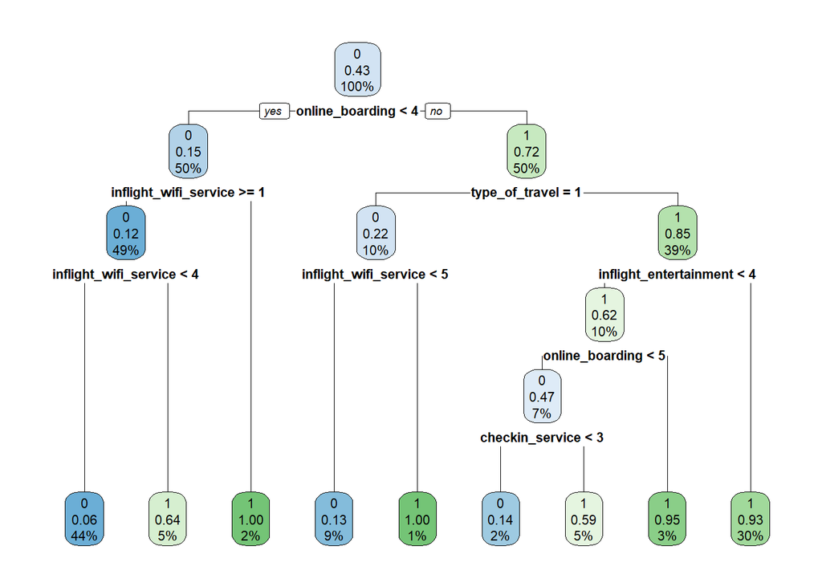

```r
library(rpart.plot)
rpart.plot(tree_model)
```

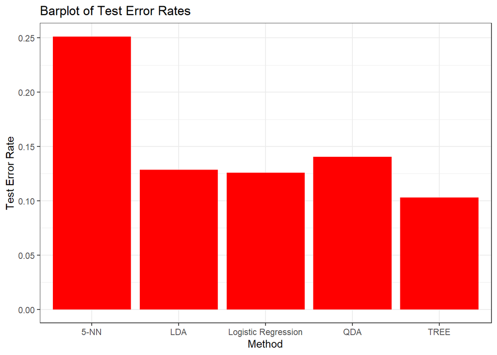

```r
library(ggplot2)

# Calculate test error rates
error_logreg <- mean(logistic_prediction_binary != test_Y)
error_lda <- mean(lda_class_prediction != test_Y)
error_qda <- mean(qda_class_prediction != test_Y)
error_5nn <- mean(five_nn_prediction != test_Y)
error_tree <- mean(predictions != test_Y)
# Create a data frame with method and error rate information
dataaaa <- data.frame(Method = c("Logistic Regression", "LDA", "QDA", "5-NN","TREE"),
                   Error_Rate = c(error_logreg, error_lda, error_qda, error_5nn, error_tree))

# Plot barplot
ggplot(dataaaa, aes(x = Method, y = Error_Rate)) +
  geom_bar(stat = "identity", fill = "Red") +
  ylab("Test Error Rate") +
  ggtitle("Barplot of Test Error Rates") +
  theme_bw()
```

# SUBSET

subset of the most explanatory coefficients

```r
log_mod <- glm(satisfaction ~ customer_type + type_of_travel+customer_class+online_boarding+inflight_wifi_service+checkin_service+onboard_service , data=dtrain , family="binomial")
summary1 <- summary (log_mod)
summary1
```

```
##
## Call:
## glm(formula = satisfaction ~ customer_type + type_of_travel +
##     customer_class + online_boarding + inflight_wifi_service +
##     checkin_service + onboard_service, family = "binomial", data = dtrain)
##
## Coefficients:
##                        Estimate Std. Error z value Pr(>|z|)
## (Intercept)           -6.882801   0.056614 -121.57   <2e-16 ***
## customer_type          1.870501   0.025892   72.24   <2e-16 ***
## type_of_travel        -2.826610   0.028715  -98.44   <2e-16 ***
## customer_class        -0.748234   0.022112  -33.84   <2e-16 ***
## online_boarding        0.656110   0.008826   74.34   <2e-16 ***
## inflight_wifi_service  0.317983   0.008027   39.62   <2e-16 ***
## checkin_service        0.369578   0.007969   46.38   <2e-16 ***
## onboard_service        0.534403   0.007912   67.54   <2e-16 ***
## ---
## Signif. codes:  0 '***' 0.001 '**' 0.01 '*' 0.05 '.' 0.1 ' ' 1
##
## (Dispersion parameter for binomial family taken to be 1)
##
##     Null deviance: 141749  on 103589  degrees of freedom
## Residual deviance:  74383  on 103582  degrees of freedom
## AIC: 74399
##
## Number of Fisher Scoring iterations: 5
```

Prediction for the new log_mod

```r
log_mod_pred <- predict(log_mod, dtest, type="response")
```

```r
# Set a threshold for classification
threshold <- 0.5

# Convert the predicted probabilities (through logistic model) to binary predictions based on the threshold
log_mod_pred_binary <- ifelse(log_mod_pred > threshold, 1, 0)

# Create a table of predicted values vs. actual values
confusion_matrix_log_mod <- table(log_mod_pred_binary, dtest$satisfaction)

# Print the confusion table
print(confusion_matrix_log_mod)
```

```
##
## log_mod_pred_binary     0     1
##                   0 12834  1880
##                   1  1672  9511
```

```r
print(mean(log_mod_pred_binary==dtest$satisfaction))
```

```
## [1] 0.8628413
```

Plot the ROC Curve for Subset

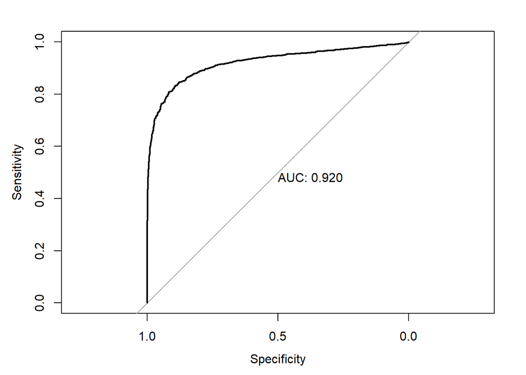

```r
library(pROC)
test_roc_sub = roc(dtest$satisfaction ~ log_mod_pred, plot = TRUE, print.auc = TRUE)
```

# Linear Discriminant Analysis

Build the *LDA* model FOR SUBSET

```r
library(MASS)

lda_model_sub <- lda(satisfaction ~ customer_type + type_of_travel+customer_class+online_boarding+inflight_wifi_service+checkin_service+onboard_service,data = dtrain)
lda_model_sub
```

```
## Call:
## lda(satisfaction ~ customer_type + type_of_travel + customer_class +
##     online_boarding + inflight_wifi_service + checkin_service +
##     onboard_service, data = dtrain)
##
## Prior probabilities of groups:
##         0         1
## 0.5668404 0.4331596
##
## Group means:
##   customer_type type_of_travel customer_class online_boarding
## 0     0.7545258     0.49190211      0.7407142        2.660314
## 1     0.8993114     0.07169441      0.2357425        4.025629
##   inflight_wifi_service checkin_service onboard_service
## 0              2.399581        3.041247        3.020062
## 1              3.154443        3.645450        3.856032
##
## Coefficients of linear discriminants:
##                              LD1
## customer_type          1.1965440
## type_of_travel        -1.6266547
## customer_class        -0.5455545
## online_boarding        0.3388626
## inflight_wifi_service  0.1602767
## checkin_service        0.1862750
## onboard_service        0.2806762
```

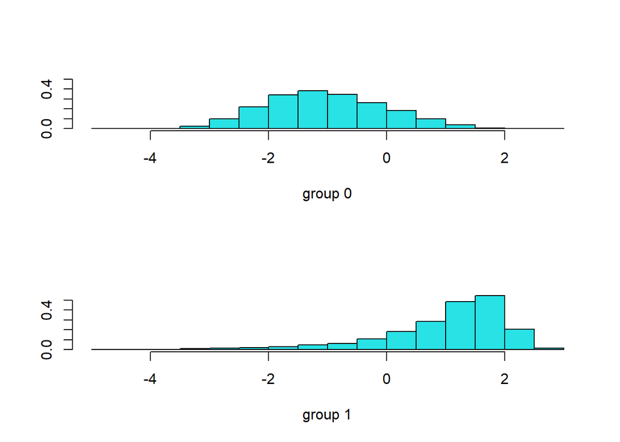

```r
plot(lda_model_sub)
```

Predict the points of the *test set* using the *LDA Model* above implemented:

```r
lda_prediction_sub = predict(lda_model_sub, dtest)
lda_class_prediction_sub = lda_prediction_sub$class
# this prediction yields the class. This will be useful to compute the confusion matrix, because there we will not need the probabilities!
```

Output the confusion matrix

```r
table(lda_class_prediction_sub, dtest$satisfaction)
```

```
##
## lda_class_prediction_sub     0     1
##                        0 12552  1758
##                        1  1954  9633
```

```r
mean(lda_class_prediction_sub==dtest$satisfaction)
```

```
## [1] 0.8566629
```

We see that we correctly predicted 85.7% of the labels of the test set.

ROC for LDA

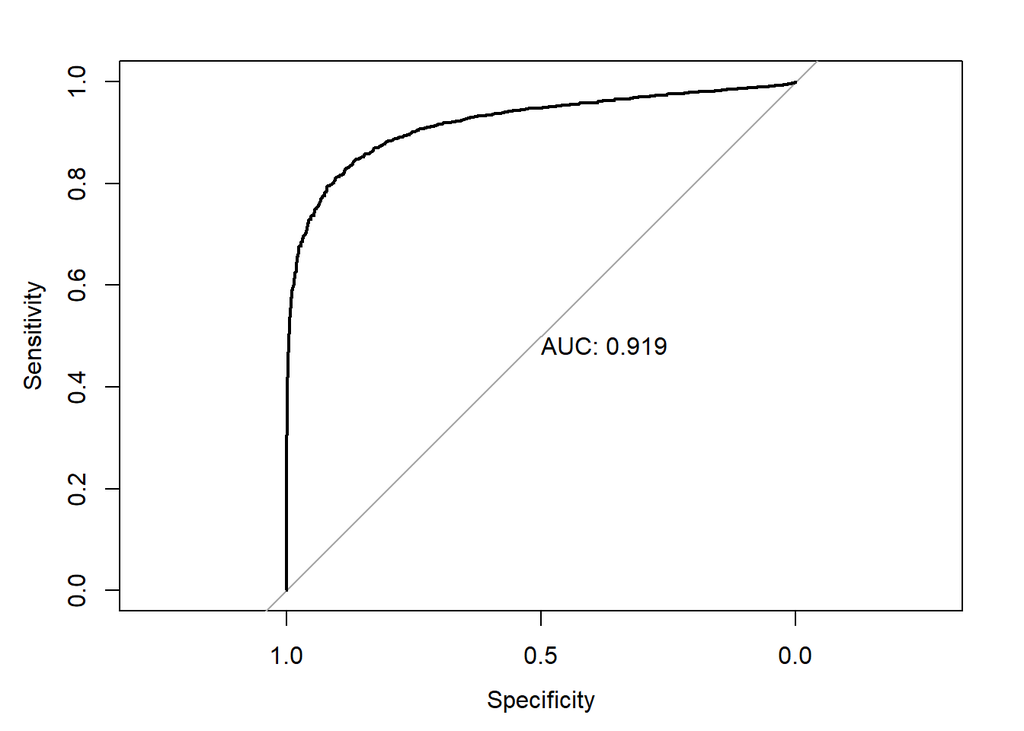

```r
lda_probabilities_prediction_sub = lda_prediction_sub$posterior[, "1"]  # either write 0 or 1!

# given the output produced by predict() we only take the "posterior" column, which gives us the predicted probabilities [0,1] that we need to build the ROC.
# to understand this: if you print "predict(lda_model, dtest)$posterior" we can see that we have two columns, which are complementary. So, we just need one column of them.



test_roc_sub = roc(dtest$satisfaction ~ lda_probabilities_prediction_sub, plot = TRUE, print.auc = TRUE)
```

# Quadratic Discriminant Analysis

```r
qda_model_sub <- qda(satisfaction ~ customer_type + type_of_travel+customer_class+online_boarding+inflight_wifi_service+checkin_service+onboard_service,data = dtrain)
qda_model_sub
```

```
## Call:
## qda(satisfaction ~ customer_type + type_of_travel + customer_class +
##     online_boarding + inflight_wifi_service + checkin_service +
##     onboard_service, data = dtrain)
##
## Prior probabilities of groups:
##         0         1
## 0.5668404 0.4331596
##
## Group means:
##   customer_type type_of_travel customer_class online_boarding
## 0     0.7545258     0.49190211      0.7407142        2.660314
## 1     0.8993114     0.07169441      0.2357425        4.025629
##   inflight_wifi_service checkin_service onboard_service
## 0              2.399581        3.041247        3.020062
## 1              3.154443        3.645450        3.856032
```

Predict the points of the *test set* using the *QDA Model* above implemented:

```r
qda_prediction_sub = predict(qda_model_sub, dtest)
qda_class_prediction_sub = qda_prediction_sub$class
```

Output the confusion matrix

```r
table(qda_class_prediction_sub, dtest$satisfaction)
```

```
##
## qda_class_prediction_sub     0     1
##                        0 12807  1900
##                        1  1699  9491
```

```r
mean(qda_class_prediction_sub==dtest$satisfaction)
```

```
## [1] 0.8610264
```

Plot the ROC Curve

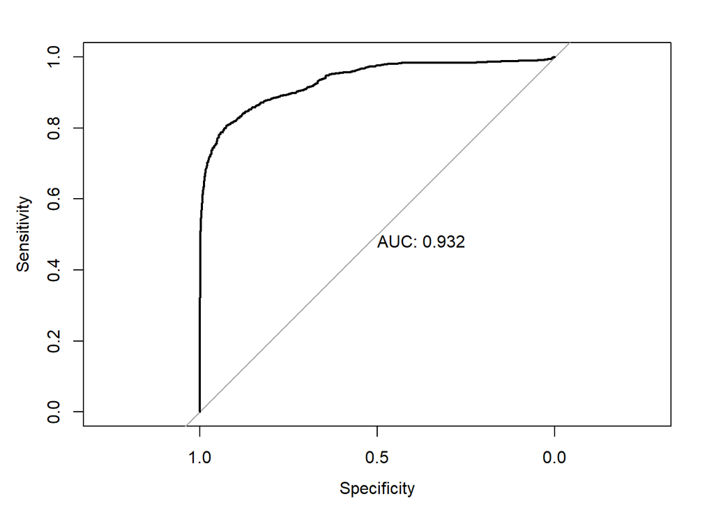

```
##
## Call:
## roc.formula(formula = dtest$satisfaction ~ qda_probabilities_prediction_sub,     plot = TRUE, print.auc = TRUE)
##
## Data: qda_probabilities_prediction_sub in 14506 controls (dtest$satisfaction 0) < 11391 cases (dtest$satisfaction 1).
## Area under the curve: 0.9317
```

```r
qda_probabilities_prediction_sub <- qda_prediction_sub$posterior[,"1"]

roc(dtest$satisfaction ~ qda_probabilities_prediction_sub, plot = TRUE, print.auc = TRUE)
```

# knn

```r
library(class)

# create Data Domain X for the TRAINING set
train_X_sub = dtrain[,c("customer_type", "type_of_travel","customer_class","online_boarding","inflight_wifi_service","checkin_service","onboard_service")]

# create Data Domain X for the TEST set
test_X_sub= dtest[,c("customer_type", "type_of_travel","customer_class","online_boarding","inflight_wifi_service","checkin_service","onboard_service")]

# labels of the training set
train_Y_sub = dtrain$satisfaction

# labels of the test set
test_Y_sub = dtest$satisfaction
```

```r
library(ggplot2)

# Define the range of k values to evaluate
k_values <- c(1,3,5,7,9)

# Initialize an empty vector to store the accuracies
accuracies_sub <- c()

# Compute the accuracy for each k value
for (k in k_values) {
  knn_prediction_sub <- knn(train_X_sub, test_X_sub, train_Y_sub, k = k)
  accuracy_sub <- mean(knn_prediction_sub == test_Y_sub)
  accuracies_sub <- c(accuracies_sub, accuracy_sub)
}
```

```r
# Create a data frame with the k values and accuracies
acc_data_sub <- data.frame(k = k_values, accuracy_sub = accuracies_sub)
```

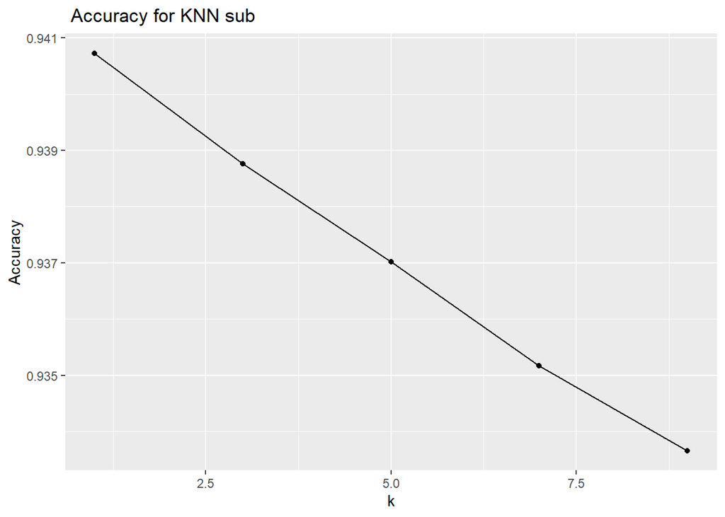

```r
# Plot the elbow plot
ggplot(acc_data_sub, aes(x = k, y = accuracy_sub)) +
  geom_line() +
  geom_point() +
  labs(x = "k", y = "Accuracy") +
  ggtitle(" Accuracy for KNN sub")
```

Error Rate plot

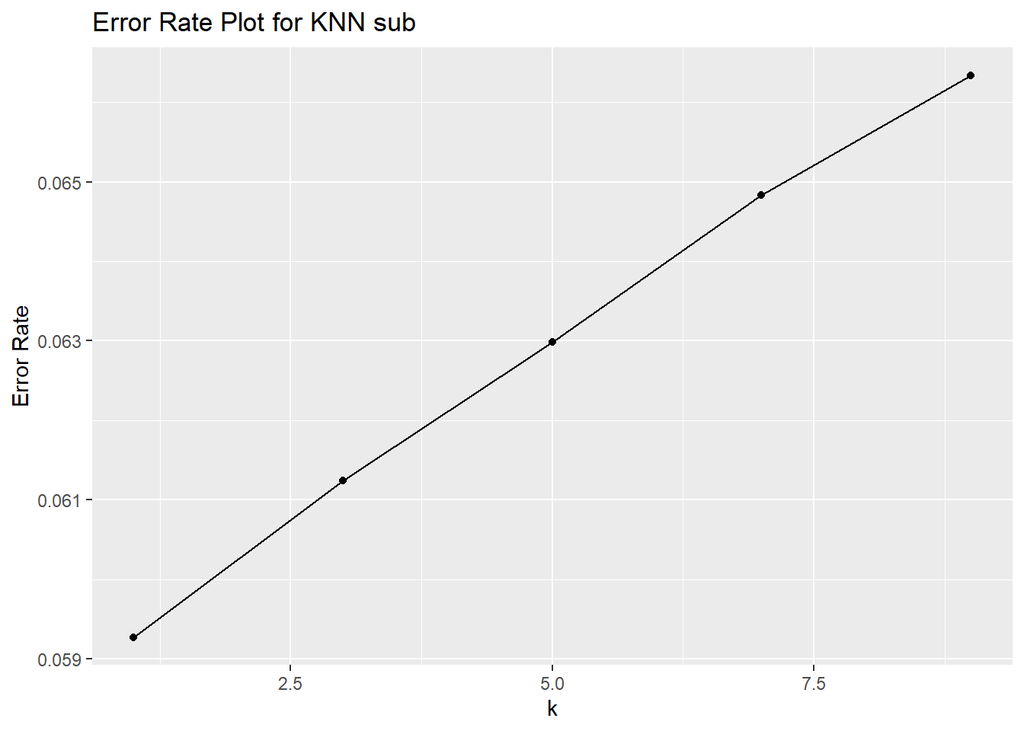

```r
# Initialize an empty vector to store the error rates
error_rates_sub <- c()
k_values <- c(1,3,5,7,9)

for (i in acc_data_sub$accuracy_sub){
error_rate_sub <- 1 - i
error_rates_sub <- c(error_rates_sub, error_rate_sub)
}


# Create a data frame with the k values and error rates
err_data_sub <- data.frame(k = k_values, error_rate_sub = error_rates_sub)

# Plot the error rate plot
ggplot(err_data_sub, aes(x = k, y = error_rate_sub)) +
  geom_line() +
  geom_point() +
  labs(x = "k", y = "Error Rate") +
  ggtitle("Error Rate Plot for KNN sub")
```

*WE CHOOSE K=5*

in the following chunk, we add prob=TRUE because we need the estimated probabilities to build the ROC later on.

```r
five_nn_prediction_sub <- knn(train_X_sub, test_X_sub, train_Y_sub, k = 5, prob=TRUE)
```

```r
confusion_matrix_knn_sub <- table(test_Y_sub, five_nn_prediction_sub)
confusion_matrix_knn_sub
```

```
##           five_nn_prediction_sub
## test_Y_sub     0     1
##          0 13847   659
##          1   978 10413
```

```r
mean(five_nn_prediction_sub==test_Y_sub)
```

```
## [1] 0.936788
```

# TREE PREDICTOR sub

```r
library(rpart)
```

```r
# Convert the response variable to a factor
dtrain$satisfaction <- as.factor(dtrain$satisfaction)
dtest$satisfaction <- as.factor(dtest$satisfaction)

# Train the rpart model
tree_model_sub <- rpart(satisfaction ~ customer_type + type_of_travel+customer_class+online_boarding+inflight_wifi_service+checkin_service+onboard_service, data = dtrain)
```

```r
# Make predictions on the test set
predictions_sub <- predict(tree_model_sub, newdata = dtest, type = "class")
```

```r
accuracy_sub <- sum(predictions_sub == dtest$satisfaction) / nrow(dtest) * 100

# Print the accuracy
cat("Accuracy: ", accuracy_sub, "%\n")
```

```
## Accuracy:  88.43495 %
```

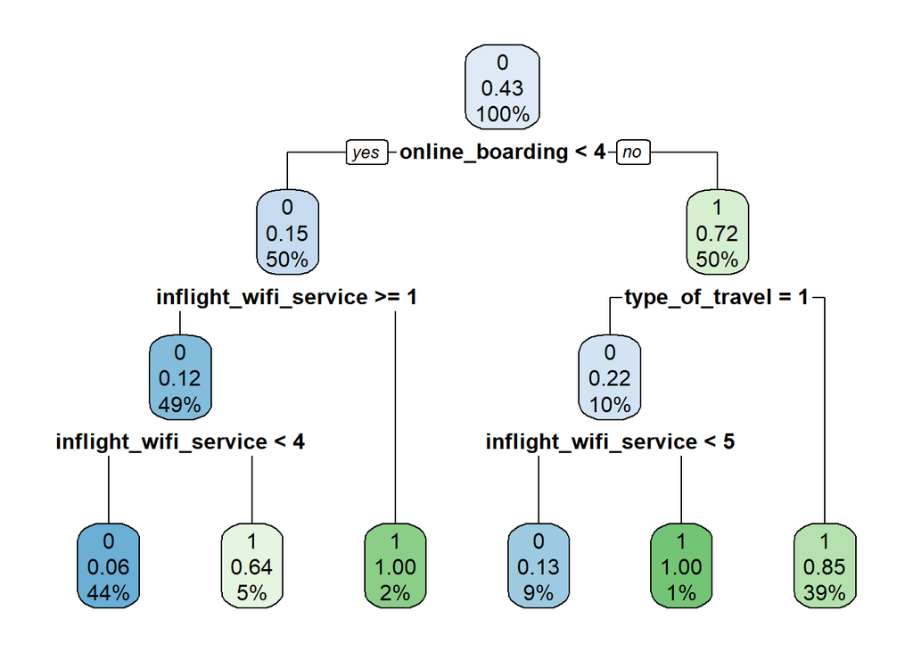

```r
library(rpart.plot)
rpart.plot(tree_model_sub)
```

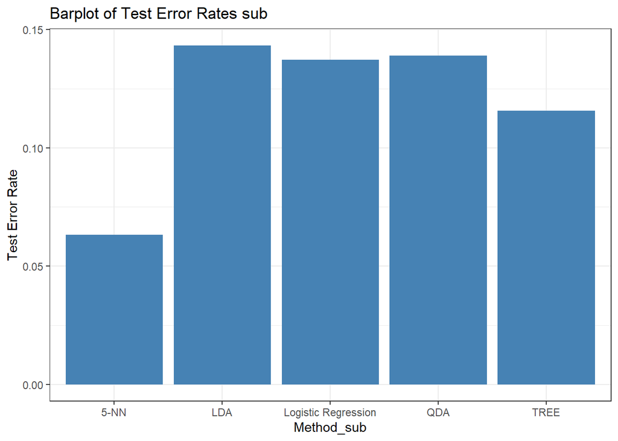

```r
library(ggplot2)

# Calculate test error rates
error_logreg_sub <- mean(log_mod_pred_binary != test_Y_sub)
error_lda_sub <- mean(lda_class_prediction_sub != test_Y_sub)
error_qda_sub <- mean(qda_class_prediction_sub != test_Y_sub)
error_5nn_sub <- mean(five_nn_prediction_sub != test_Y_sub)
error_tree_sub <- mean(predictions_sub != test_Y_sub)
# Create a data frame with method and error rate information
dataaaa_sub <- data.frame(Method_sub = c("Logistic Regression", "LDA", "QDA", "5-NN","TREE"),
                   Error_Rate_sub = c(error_logreg_sub, error_lda_sub, error_qda_sub, error_5nn_sub, error_tree_sub))

# Plot barplot
ggplot(dataaaa_sub, aes(x = Method_sub, y = Error_Rate_sub)) +
  geom_bar(stat = "identity", fill = "steelblue") +
  ylab("Test Error Rate") +
  ggtitle("Barplot of Test Error Rates sub") +
  theme_bw()
```

```r
#dataaaa$Dataset <- "Full Dataset"  # Add a new column to specify the dataset


#dataaaa_sub$Dataset <- "Subset Dataset"  # Add a new column to specify the dataset


#colnames(dataaaa_sub)[colnames(dataaaa_sub) == "Error_Rate_sub"] <- "Error_Rate"
# Combine the data frames
#merged_data <- rbind(dataaaa, dataaaa_sub)

# Plot the merged barplot
#ggplot(merged_data, aes(x = Method, y = Error_Rate, fill = Dataset)) +
  #geom_bar(stat = "identity", position = "dodge") +
  #ylab("Test Error Rate") +
  #ggtitle("Barplot of Test Error Rates") +
  #theme_bw()
```

# interpretation